# Piezómetros de la Provincia de Almería

Violeta Garrido Martínez

2026-02-24

https://github.com/violetagm/ecoinf_violetagarrido

## Piezómetros de Almería

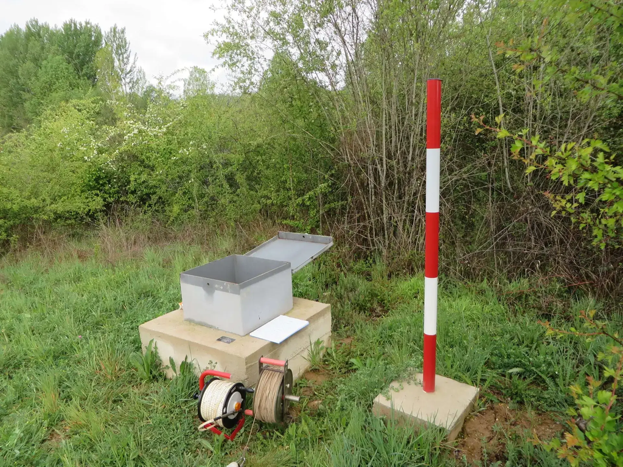

**Piezómetro de la red de seguimiento del IGME**

## Masas de agua subterráneas de la provincia de Almería

Dentro de la provincia de Almería existen varias masas de agua subterráneas. Por extensión, la mayor es la de *Campo de Dalías-Sierra Gádor*, muy vulnerable a la intrusión marina (Pulido Bosch, 1997).

Este es el listado de todas las masas de agua subterráneas de la provincia que están monitoreadas por los piezómetros de la red de seguimiento del MITECO.

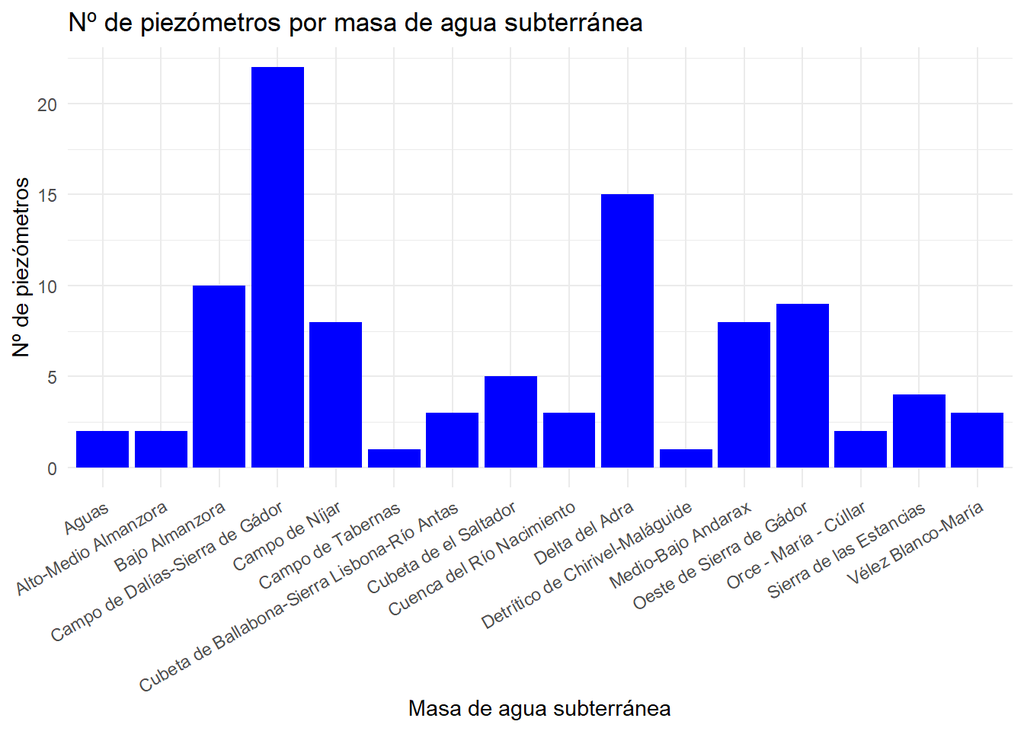

| Masa de agua subterránea | Número de piezómetros |
| --- | --- |
| Aguas | 2 |
| Alto-Medio Almanzora | 2 |
| Bajo Almanzora | 10 |
| Campo de Dalías-Sierra de Gádor | 22 |
| Campo de Níjar | 8 |
| Campo de Tabernas | 1 |
| Cubeta de Ballabona-Sierra Lisbona-Río Antas | 3 |
| Cubeta de el Saltador | 5 |
| Cuenca del Río Nacimiento | 3 |
| Delta del Adra | 15 |
| Detrítico de Chirivel-Maláguide | 1 |
| Medio-Bajo Andarax | 8 |
| Oeste de Sierra de Gádor | 9 |
| Orce - María - Cúllar | 2 |
| Sierra de las Estancias | 4 |
| Vélez Blanco-María | 3 |

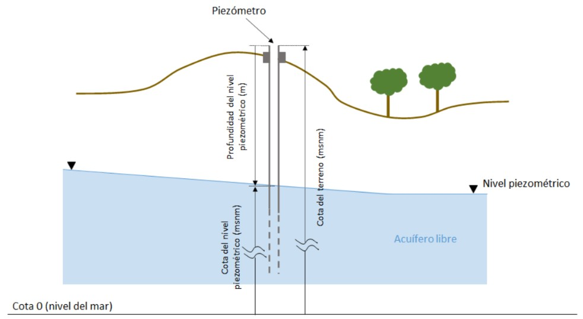

**Esquema de los niveles piezométricos elaborado por el MITECO**

## Problemática de los acuíferos

Dentro de la provincia de Almería hay gran extensión de invernaderos. En ella se genera el 60% de la producción hortícola de Andalucía. Y la fuente principal de agua en la provincia proviene de las masas de agua subterráneas, debido a la escasez de lluvia y a la imposibilidad de depender de ríos y embalses (Cerrillo López, 2009).

Toda explotación de un acuífero conlleva cambios en el flujo natural de las aguas subterráneas. El principal efecto es la disminución del nivel freático, junto con el agotamiento de las reservas. Cualquier explotación de un acuífero, incluso si no es intensiva, produce una reducción de las reservas de agua y del caudal de salida del acuífero (Custodio et al., 2019).

[interactive chart not shown]

## Bibliografía

Cerrillo López, M. I. (2009). *Acuíferos poniente: Un tesoro oculto bajo tus pies*. Agencia Andaluza del Agua.

Custodio, E., Sahuquillo, A., & Albiac, J. (2019). Sustainability of intensive groundwater development: Experience in Spain. *Sustainable Water Resources Management*, *5*(1), 11–26. https://doi.org/10.1007/s40899-017-0105-8

Pulido Bosch, A. (1997). Los recursos hídricos de la provincia de Almería. *Actas Del I y II Seminario Del Agua, 1997, ISBN 84-8108-128-0, Págs. 65-90*, 65–90. https://dialnet.unirioja.es/servlet/articulo?codigo=566694